# 732A90: Computational Statistics

Computer lab4 - Group11

Sofie Jörgensen, Oriol Garrobé Guilera, David Hrabovszki

19 February 2020

# Question 1: Computations with Metropolis-Hastings

In this question we define the density function $f(x)$ as

$$f(x)\propto x^5e^{-x}, \quad x>0.$$
This density function is known up to some constant of proportionality, which is 120.

### 1.

In the first step we use the Metropolis-Hastings algorithm to generate samples from the posterior distribution $f(x)$ by using the log-normal $LN(X_t,1)$ as the proposal distribution. We take 1 as a starting point, because we expect this value to be within the range of possible values of the distribution defined above.

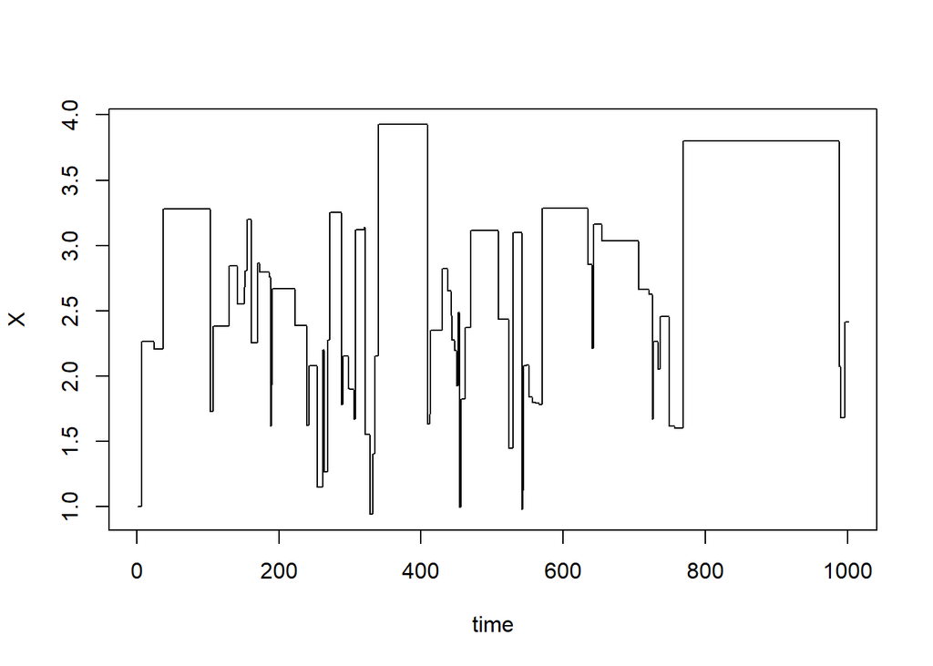

Metropolis-Hastings sampler with log-normal proposal

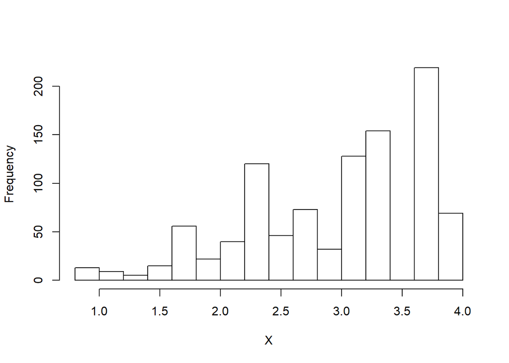

Histogram of generated samples with log-normal proposal (MH sampler)